# Tanımlayıcı İstatistik

2024-04-16

## Temel İstatistik

*Kullanılan veri kümesi*

```r
str(diamonds)
```

```
## tibble [53,940 × 10] (S3: tbl_df/tbl/data.frame)
##  $ carat  : num [1:53940] 0.23 0.21 0.23 0.29 0.31 0.24 0.24 0.26 0.22 0.23 ...
##  $ cut    : Ord.factor w/ 5 levels "Fair"<"Good"<..: 5 4 2 4 2 3 3 3 1 3 ...
##  $ color  : Ord.factor w/ 7 levels "D"<"E"<"F"<"G"<..: 2 2 2 6 7 7 6 5 2 5 ...
##  $ clarity: Ord.factor w/ 8 levels "I1"<"SI2"<"SI1"<..: 2 3 5 4 2 6 7 3 4 5 ...
##  $ depth  : num [1:53940] 61.5 59.8 56.9 62.4 63.3 62.8 62.3 61.9 65.1 59.4 ...
##  $ table  : num [1:53940] 55 61 65 58 58 57 57 55 61 61 ...
##  $ price  : int [1:53940] 326 326 327 334 335 336 336 337 337 338 ...
##  $ x      : num [1:53940] 3.95 3.89 4.05 4.2 4.34 3.94 3.95 4.07 3.87 4 ...
##  $ y      : num [1:53940] 3.98 3.84 4.07 4.23 4.35 3.96 3.98 4.11 3.78 4.05 ...
##  $ z      : num [1:53940] 2.43 2.31 2.31 2.63 2.75 2.48 2.47 2.53 2.49 2.39 ...
```

Değişkenler aşağıdaki gibidir:

Format **53940 satır ve 10 değişken içeren bir veri:**

**fiyat (price)**: ABD doları cinsinden fiyat ($326–$18,823)

**karat (carat)**: Elmasın ağırlığı (0.2–5.01)

**kesim kalitesi (cut)**: Kesimin kalitesi (Fair, Good, Very Good, Premium, Ideal)

**renk (color)**: Elmasın rengi, D (en iyi) ile J (en kötü) arası

berraklık (clarity): Elmasın ne kadar net olduğunun ölçüsü (I1 (en kötü), SI2, SI1, VS2, VS1, VVS2, VVS1, IF (en iyi))

**x**: Uzunluk mm cinsinden (0–10.74)

**y**: Genişlik mm cinsinden (0–58.9)

**z**: Derinlik mm cinsinden (0–31.8)

**derinlik (depth)**: Toplam derinlik yüzdesi = z / ortalama(x, y) = 2 * z / (x + y) (43–79)

**masa (table**): Elmasın en geniş noktasına göre üst genişliği (43–95)

*Değişkenlere ilişkin temel bazı istatistikleri*

```r
summary(diamonds)
```

```
##      carat               cut        color        clarity          depth
##  Min.   :0.2000   Fair     : 1610   D: 6775   SI1    :13065   Min.   :43.00
##  1st Qu.:0.4000   Good     : 4906   E: 9797   VS2    :12258   1st Qu.:61.00
##  Median :0.7000   Very Good:12082   F: 9542   SI2    : 9194   Median :61.80
##  Mean   :0.7979   Premium  :13791   G:11292   VS1    : 8171   Mean   :61.75
##  3rd Qu.:1.0400   Ideal    :21551   H: 8304   VVS2   : 5066   3rd Qu.:62.50
##  Max.   :5.0100                     I: 5422   VVS1   : 3655   Max.   :79.00
##                                     J: 2808   (Other): 2531
##      table           price             x                y
##  Min.   :43.00   Min.   :  326   Min.   : 0.000   Min.   : 0.000
##  1st Qu.:56.00   1st Qu.:  950   1st Qu.: 4.710   1st Qu.: 4.720
##  Median :57.00   Median : 2401   Median : 5.700   Median : 5.710
##  Mean   :57.46   Mean   : 3933   Mean   : 5.731   Mean   : 5.735
##  3rd Qu.:59.00   3rd Qu.: 5324   3rd Qu.: 6.540   3rd Qu.: 6.540
##  Max.   :95.00   Max.   :18823   Max.   :10.740   Max.   :58.900
##
##        z
##  Min.   : 0.000
##  1st Qu.: 2.910
##  Median : 3.530
##  Mean   : 3.539
##  3rd Qu.: 4.040
##  Max.   :31.800
##
```

*Sayısal değişkenler için Merkezi Dağılım tablosu*

```r
numeric_columns <- sapply(diamonds, is.numeric)
numeric_data <- diamonds[, numeric_columns]

ort <- sapply(numeric_data, FUN=mean)
medyen <- sapply(numeric_data, FUN=median)
varyans <- sapply(numeric_data, FUN=var)
stsapma <- sapply(numeric_data, FUN=sd)
min <- sapply(numeric_data, FUN=min)
max <- sapply(numeric_data, FUN=max)
round(cbind(min,max,ort,medyen,varyans,stsapma),digits=2)
```

```
##         min      max     ort  medyen     varyans stsapma
## carat   0.2     5.01    0.80    0.70        0.22    0.47
## depth  43.0    79.00   61.75   61.80        2.05    1.43
## table  43.0    95.00   57.46   57.00        4.99    2.23
## price 326.0 18823.00 3932.80 2401.00 15915629.42 3989.44
## x       0.0    10.74    5.73    5.70        1.26    1.12
## y       0.0    58.90    5.73    5.71        1.30    1.14
## z       0.0    31.80    3.54    3.53        0.50    0.71
```

```r
sapply(numeric_data, function(x) max(x) - min(x))
```

```
##    carat    depth    table    price        x        y        z
##     4.81    36.00    52.00 18497.00    10.74    58.90    31.80
```

**Değişkenlik katsayısı (Coefficient of variation)**

```r
# Create the function.
getdk <- function(d) {
   k <- 100*(sd(d)/mean(d))
}
d <- c(diamonds$carat)
dk <- getdk(d)
print(dk)
```

```
## [1] 59.40439
```

**Histogram**

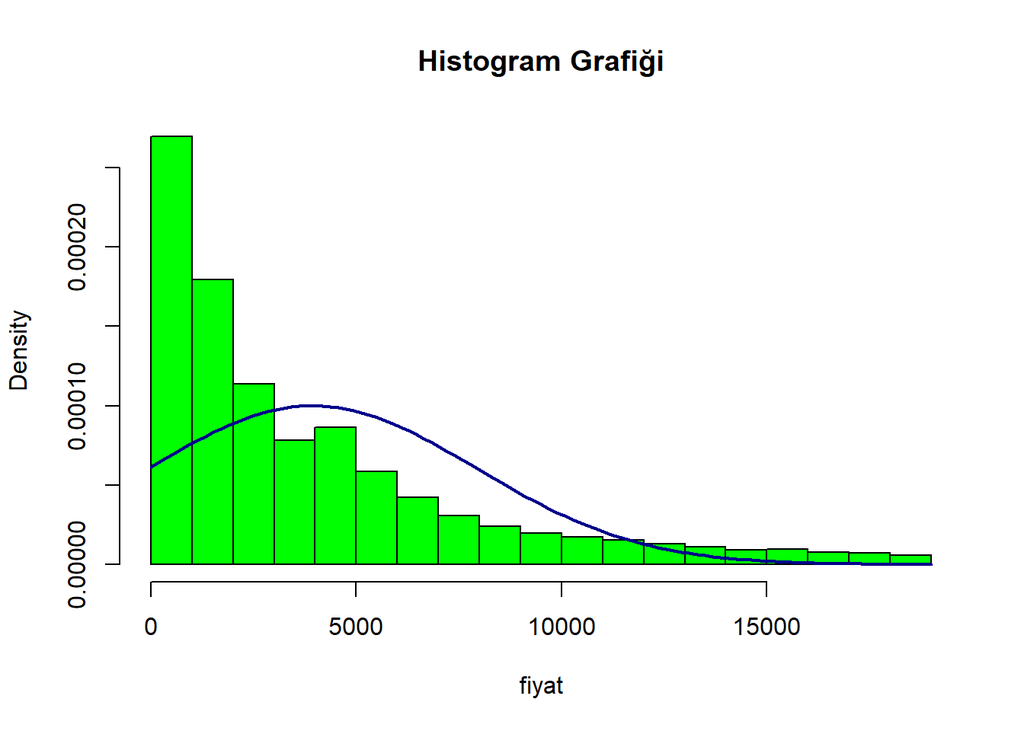

```r
hist(diamonds$price,prob=T,main="Histogram Grafiği", xlab="fiyat",col="green")
curve(dnorm(x, mean=mean(diamonds$price), sd=sd(diamonds$price)), add=TRUE,col="darkblue", lwd=2)
```

**Frekans (Frequency)**

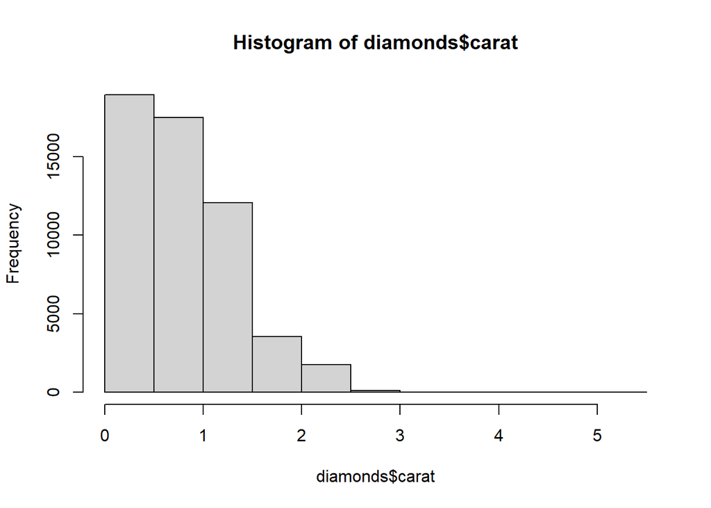

```r
hist(diamonds$carat)
hist(diamonds$carat)
```

```r
# color sütunundaki verilerin frekans tablosunu oluşturun
color_frekans <- table(diamonds$cut)

# Oluşturulan frekans tablosunu görüntüleyin
print(color_frekans)
```

```
##
##      Fair      Good Very Good   Premium     Ideal
##      1610      4906     12082     13791     21551
```

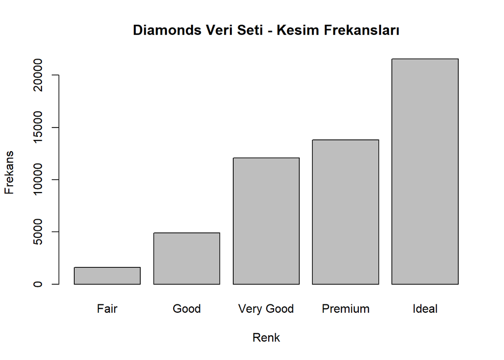

```r
# Sütun grafiğini çizin
barplot(color_frekans, main="Diamonds Veri Seti - Kesim Frekansları", xlab="Renk", ylab="Frekans")
```

**Kovaryans**

```r
cov(diamonds$carat,diamonds$price)
```

```
## [1] 1742.765
```

**Korelasyon Katsayısı**

```r
cor(diamonds$carat,diamonds$price)
```

```
## [1] 0.9215913
```

**Carat Dağılım Grafiği**

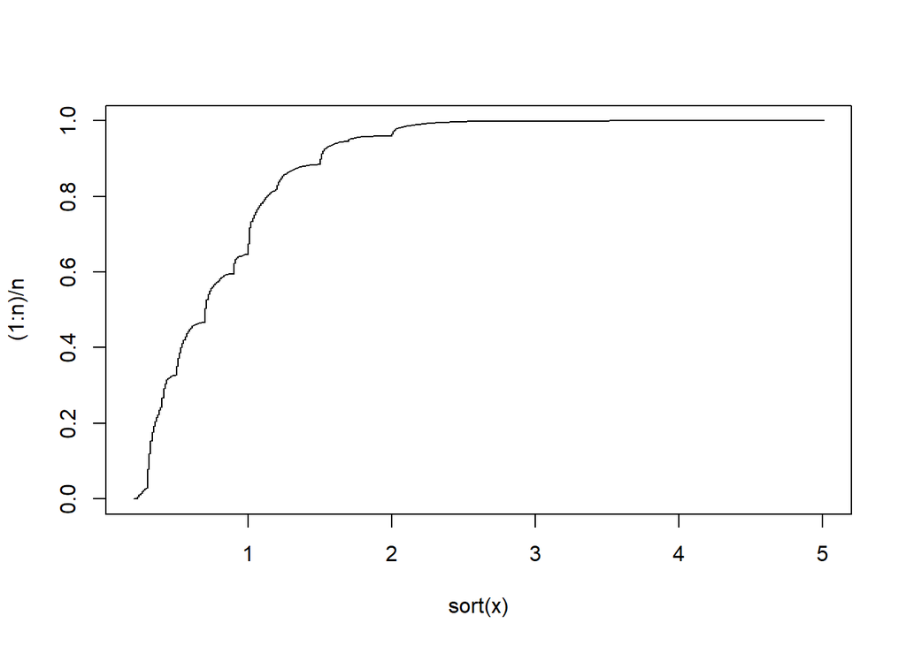

```r
x<-diamonds$carat
n<-length(x)
plot(sort(x),(1:n)/n,type="s",ylim=c(0,1))
```

**Fiyat Dağılım Grafiği**

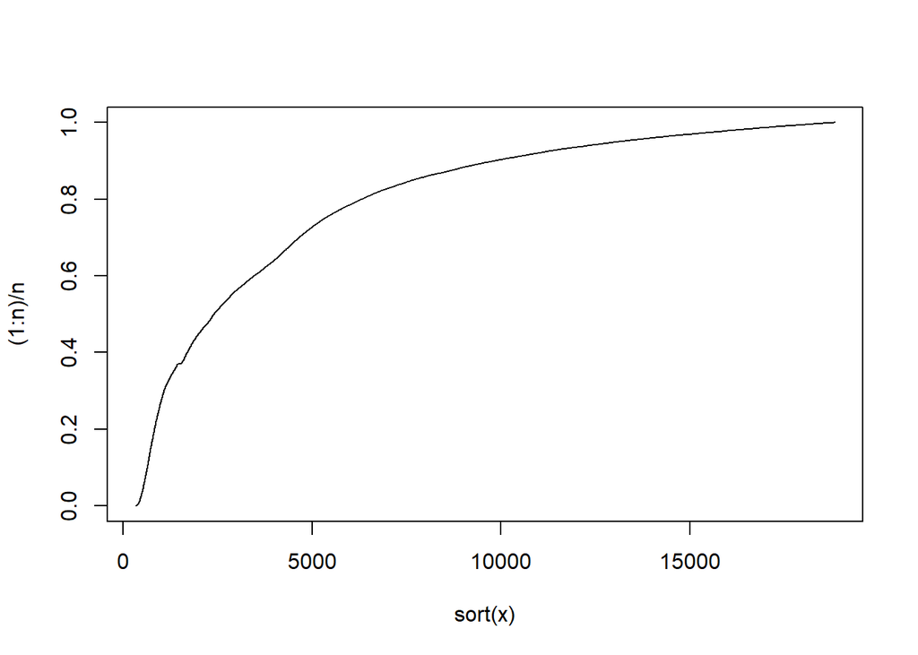

```r
x<-diamonds$price
n<-length(x)
plot(sort(x),(1:n)/n,type="s",ylim=c(0,1))
```

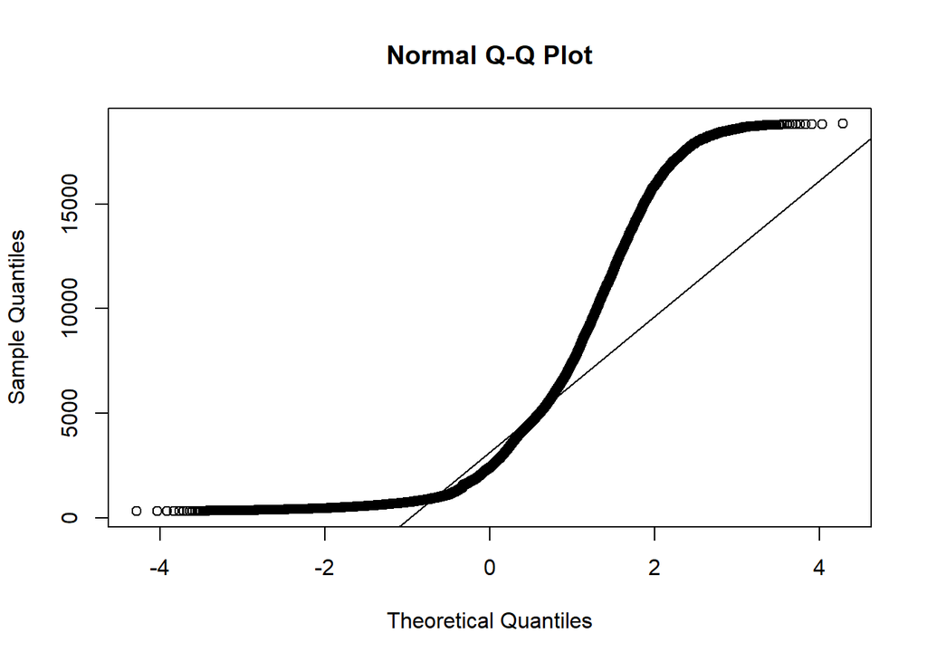

```r
qqnorm(diamonds$price)
qqline(diamonds$price)
```

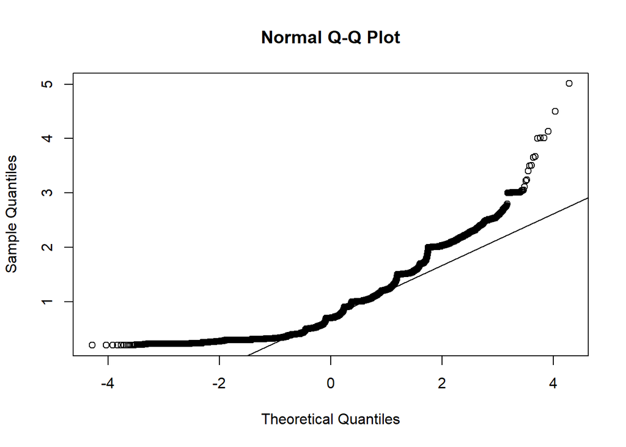

```r
qqnorm(diamonds$carat)
qqline(diamonds$carat)
```

**Skewness Değeri**

```r
round(sapply(numeric_data,skewness),digits=2)
```

```
## carat depth table price     x     y     z
##  1.12 -0.08  0.80  1.62  0.38  2.43  1.52
```

*Normal dağılıma sahip bir değişkenin skewness değerinin sıfıra yakın olması gerekmektedir. Skewness değerinin pozitif olarak artması, dağılımın sağa doğru uzayan bir kuyruğu olduğunu, negatif olarak artmasıysa sola doğru uzayan bir kuyruğu olduğunu göstermektedir*

**Derinlik Normal Dağılım Grafiği** *0’a en yakın olan depth değeri için normal dağılım tablosu aşağıdaki gibidir.*

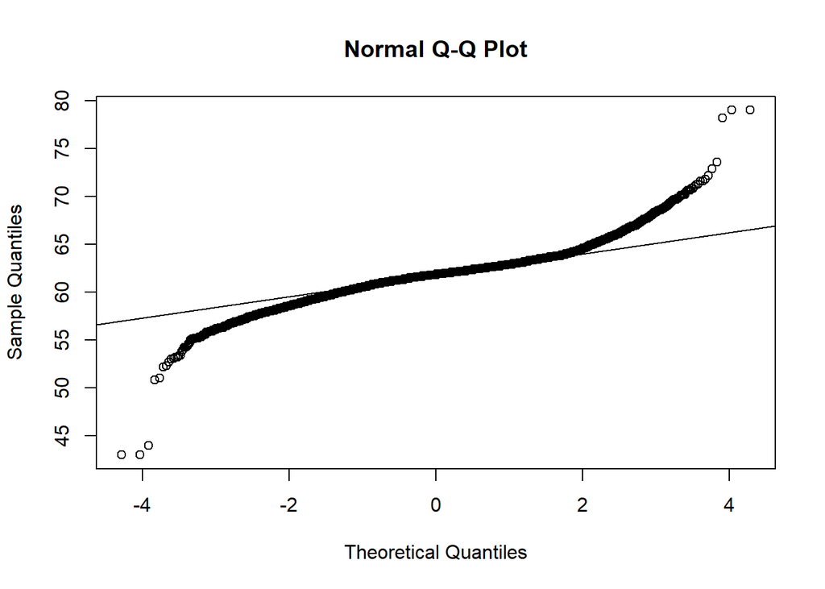

```r
qqnorm(diamonds$depth)
qqline(diamonds$depth)
```